# Bayes Optimisation for XGBoost

This is an example of using the [rBayesianOptimization](https://cran.r-project.org/web/packages/rBayesianOptimization/index.html) package for hyperparameter tuning. Uses the German credit data from the [UCI Machine Learning Repository](https://archive.ics.uci.edu/ml/index.php). Model built using gradient-boosted decision trees via [XGBoost](https://xgboost.ai/).

# Data Loading and Setup

```r
# load libraries for the work, comments indicate what each is for
suppressPackageStartupMessages({
    library(dplyr) # data wrangling
    library(data.table) # for handling evaluation logs from xgboost
    library(tidyr) # reshaping data sets
    library(purrr) # functional programming package
    library(corrplot) # easy plotting of correlation matrix
    library(caret) # machine learning
    library(xgboost) # machine learning
    library(Matrix) # for creating model matrices
    library(readr) # for reading data direct to tibbles
    library(ggplot2) # data viz
    library(viridis) # colour palettes for plots
    library(stringi) # string manipulation
    library(pROC) # handling ROC curves
    library(forcats) # managing factors/categorical variables
    library(knitr) # pretty printing of tables with kable()
    library(rBayesianOptimization)
    source("./R/print_conf_matrix.R")
})
```

Now get the data files from UCI, unless they are already present in the `./data/` directory.

```r
# url for the main dataset
data_url <- "https://archive.ics.uci.edu/ml/machine-learning-databases/statlog/german/german.data"
# the data dictionary
data_dict_url <- "https://archive.ics.uci.edu/ml/machine-learning-databases/statlog/german/german.doc"
# local filepaths
data_path <- paste0("./data/", basename(data_url))
dict_path <- paste0("./data/", basename(data_dict_url))
# download files if not already present
if (!file.exists(data_path)) {
    download.file(data_url, data_path)
}
if (!file.exists(dict_path)) {
    download.file(data_dict_url, dict_path)
}
# column names taken from the data dictionary, slightly changed to keep lengths
# reasonable
column_names <- c("acct_status", "duration", "credit_history",
                  "purpose", "amount", "savings_acct",
                  "present_emp_since", "pct_of_income", "sex_status",
                  "other_debtor_guarantor", "resident_since", "property",
                  "age", "other_debts", "housing",
                  "num_existing_credits", "job", "num_dependents",
                  "telephone", "foreign_worker", "outcome")
# set the column types manually to avoid any coercion errors
column_types <- c("ciccicciccicicciciccc")
raw_df <- read_delim(data_path,
                     delim = " ",
                     col_names = column_names,
                     col_types = column_types)
```

# Exploratory Data Analysis

`readr::read_delim()` does not convert strings to factors automatically. This means I must set factor levels manually, but this allows for greater control over the levels and means I can give them more informative names from the start. An alternative would be to use the base `utils::read.table()` function, which defaults to `stringsAsFactors = TRUE`, and then rename factors later.

```r
# details of the factors are taken from the data dictionary
# a couple of these raise warnings because there are no rows with the given
# Axx code. These manipulations use functions from the forcats package,
# which makes factors much easier
clean_df <- raw_df %>%
    mutate(acct_status = fct_recode(acct_status,
                                    overdrawn = "A11", below_200DM = "A12",
                                    over_200DM = "A13", no_acct = "A14"),
           credit_history = fct_recode(credit_history,
                                       none_taken_all_paid = "A30",
                                       all_paid_this_bank = "A31",
                                       all_paid_duly = "A32",
                                       past_delays = "A33",
                                       critical_acct = "A34"),
           purpose = fct_recode(purpose,
                                car_new = "A40", car_used = "A41",
                                furniture_equipment  = "A42",
                                radio_tv = "A43",
                                dom_appliance = "A44",
                                repairs = "A45",
                                education = "A46",
                                vacation = "A47",
                                retraining = "A48",
                                business = "A49",
                                others = "A410"),
           savings_acct = fct_recode(savings_acct,
                                     to_100DM = "A61",
                                     to_500DM = "A62",
                                     to_1000DM = "A63",
                                     over_1000DM = "A64",
                                     unknwn_no_acct = "A65"),
           present_emp_since = fct_recode(present_emp_since,
                                          unemployed = "A71",
                                          to_1_yr = "A72",
                                          to_4_yrs = "A73",
                                          to_7_yrs = "A74",
                                          over_7_yrs = "A75"),
           sex_status = fct_recode(sex_status,
                                   male_divorced = "A91",
                                   female_married = "A92",
                                   male_single = "A93",
                                   male_married = "A94",
                                   female_single = "A95"),
           other_debtor_guarantor = fct_recode(other_debtor_guarantor,
                                               none = "A101",
                                               co_applicant = "A102",
                                               guarantor = "A103"),
           property = fct_recode(property,
                                 real_estate = "A121",
                                 savings_insurance = "A122",
                                 car_other = "A123",
                                 unknwn_none = "A124"),
           other_debts = fct_recode(other_debts,
                                    bank = "A141",
                                    stores = "A142",
                                    none = "A143"),
           housing = fct_recode(housing,
                                rent = "A151",
                                own = "A152",
                                for_free = "A153"),
           job = fct_recode(job,
                            unemp_unskilled_nonres = "A171",
                            unskilled_res = "A172",
                            skilled_official = "A173",
                            mgmt_highqual = "A174"),
           telephone = fct_recode(telephone,
                                  no = "A191",
                                  yes = "A192"),
           foreign_worker = fct_recode(foreign_worker,
                                       yes = "A201",
                                       no = "A202"),
           outcome = fct_recode(outcome,
                                good = "1",
                                bad = "2")) %>%
    # add another factor for gender, a simplification of sex_status, which can
    # then be compared during EDA
    mutate(gender = fct_collapse(sex_status,
                                 male = "male_divorced",
                                 male = "male_single",
                                 male = "male_married",
                                 female = "female_married",
                                 female = "female_single"))
```

```
Unknown levels in `f`: A47Unknown levels in `f`: A95Unknown levels in `f`: female_single
```

```r
glimpse(clean_df)
```

```
Observations: 1,000
Variables: 22
$ acct_status            <fct> overdrawn, below_200DM, no_acct, overdrawn, overdrawn, no_acct, no_acct, below_200DM, no_...
$ duration               <int> 6, 48, 12, 42, 24, 36, 24, 36, 12, 30, 12, 48, 12, 24, 15, 24, 24, 30, 24, 24, 9, 6, 10, ...
$ credit_history         <fct> critical_acct, all_paid_duly, critical_acct, all_paid_duly, past_delays, all_paid_duly, a...
$ purpose                <fct> radio_tv, radio_tv, education, furniture_equipment, car_new, education, furniture_equipme...
$ amount                 <int> 1169, 5951, 2096, 7882, 4870, 9055, 2835, 6948, 3059, 5234, 1295, 4308, 1567, 1199, 1403,...
$ savings_acct           <fct> unknwn_no_acct, to_100DM, to_100DM, to_100DM, to_100DM, unknwn_no_acct, to_1000DM, to_100...
$ present_emp_since      <fct> over_7_yrs, to_4_yrs, to_7_yrs, to_7_yrs, to_4_yrs, to_4_yrs, over_7_yrs, to_4_yrs, to_7_...
$ pct_of_income          <int> 4, 2, 2, 2, 3, 2, 3, 2, 2, 4, 3, 3, 1, 4, 2, 4, 4, 2, 4, 3, 4, 2, 1, 3, 2, 1, 4, 3, 3, 3,...
$ sex_status             <fct> male_single, female_married, male_single, male_single, male_single, male_single, male_sin...
$ other_debtor_guarantor <fct> none, none, none, guarantor, none, none, none, none, none, none, none, none, none, none, ...
$ resident_since         <int> 4, 2, 3, 4, 4, 4, 4, 2, 4, 2, 1, 4, 1, 4, 4, 2, 4, 3, 2, 2, 4, 3, 3, 4, 1, 2, 4, 3, 2, 4,...
$ property               <fct> real_estate, real_estate, real_estate, savings_insurance, unknwn_none, unknwn_none, savin...
$ age                    <int> 67, 22, 49, 45, 53, 35, 53, 35, 61, 28, 25, 24, 22, 60, 28, 32, 53, 25, 44, 31, 48, 44, 4...
$ other_debts            <fct> none, none, none, none, none, none, none, none, none, none, none, none, none, none, none,...
$ housing                <fct> own, own, own, for_free, for_free, for_free, own, rent, own, own, rent, rent, own, own, r...
$ num_existing_credits   <int> 2, 1, 1, 1, 2, 1, 1, 1, 1, 2, 1, 1, 1, 2, 1, 1, 2, 3, 1, 1, 3, 1, 2, 1, 2, 1, 1, 2, 1, 2,...
$ job                    <fct> skilled_official, skilled_official, unskilled_res, skilled_official, skilled_official, un...
$ num_dependents         <int> 1, 1, 2, 2, 2, 2, 1, 1, 1, 1, 1, 1, 1, 1, 1, 1, 1, 1, 1, 2, 1, 2, 2, 1, 1, 1, 1, 1, 1, 1,...
$ telephone              <fct> yes, no, no, no, no, yes, no, yes, no, no, no, no, yes, no, no, no, no, no, yes, yes, yes...
$ foreign_worker         <fct> yes, yes, yes, yes, yes, yes, yes, yes, yes, yes, yes, yes, yes, yes, yes, yes, yes, yes,...
$ outcome                <fct> good, bad, good, good, bad, good, good, good, good, bad, bad, bad, good, bad, good, bad, ...
$ gender                 <fct> male, female, male, male, male, male, male, male, male, male, female, female, female, mal...
```

I want to check for homogeneity and/or small classes among the categorical variables.

```r
factor_varnames <- colnames(clean_df)[sapply(clean_df, is.factor)]
cat_pct <- 0.02
walk(factor_varnames, function(x) {
    tmp_tbl <- fct_count(clean_df[[x]]) %>%
        mutate(pct = n/sum(n))
    if (min(tmp_tbl[["pct"]]) < cat_pct) {
        print(paste0(x, " has categories with less than ",
                     as.integer(100 * cat_pct), "% of observations."))
        print(table(clean_df[[x]])/nrow(clean_df))
    }
})
```

```
[1] "purpose has categories with less than 2% of observations."

            car_new            car_used              others furniture_equipment            radio_tv       dom_appliance
              0.234               0.103               0.012               0.181               0.280               0.012
            repairs           education          retraining            business
              0.022               0.050               0.009               0.097
```

Now I can start visualising the distributions of the variables to see if any other patterns emerge.

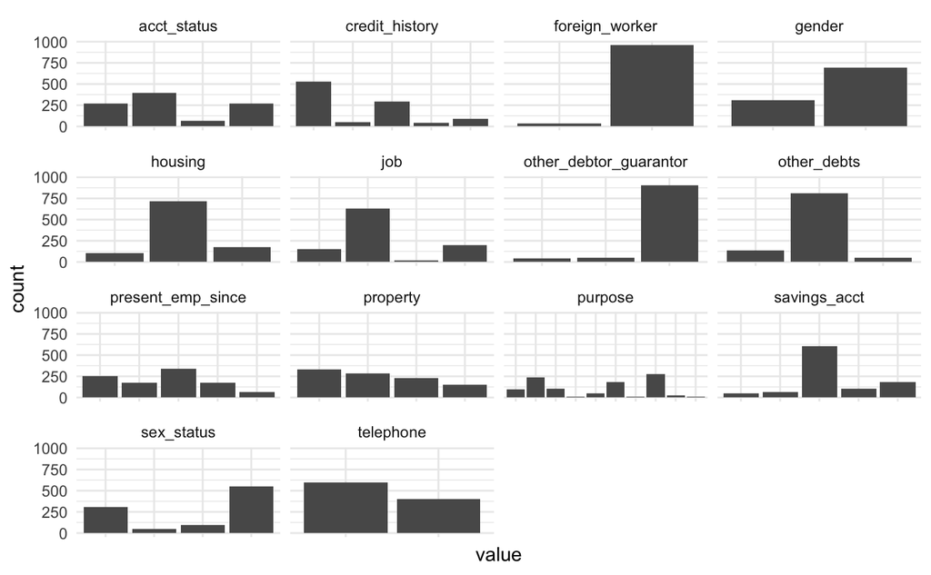

```r
# start with bar plots for the factor vars
clean_df %>%
    dplyr::select(-outcome) %>%
    select_if(is.factor) %>%
    mutate_all(as.character) %>% # this is to avoid an error about factor
    # attributes being lost, but this step isn't
    # strictly necessary as gather would coerce
    # to character anyway
    gather(key = "feature") %>%
    ggplot(aes(x = value)) +
    geom_bar() +
    facet_wrap(~ feature, scales = "free_x") +
    theme_minimal() +
    theme(axis.text.x = element_blank())
```

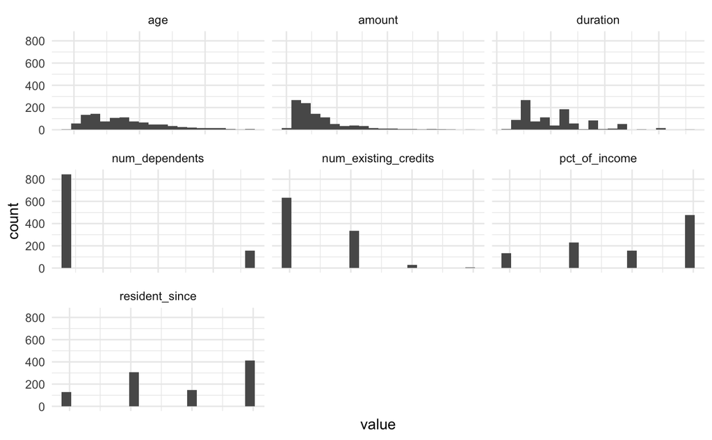

```r
# then histograms for integers
clean_df %>%
    dplyr::select_if(is.integer) %>%
    gather(key = "feature") %>%
    ggplot(aes(x = value)) +
    geom_histogram(bins = 20) +
    facet_wrap(~ feature, scales = "free_x") +
    theme_minimal() +
    theme(axis.text.x = element_blank())
```

`foreign_worker`, `other_debtor_guarantor`, and `sex_status` seem to have some very small categories, and are worth more examination.

```r
walk(c("foreign_worker", "other_debtor_guarantor", "sex_status"),
     function(x) {
         tmp_tbl <- fct_count(clean_df[[x]]) %>%
             mutate(pct = n/sum(n))
         print(paste0("Proportions for variable: ", x))
         print(table(clean_df[[x]])/nrow(clean_df))
     })
```

```
[1] "Proportions for variable: foreign_worker"

  yes    no
0.963 0.037
[1] "Proportions for variable: other_debtor_guarantor"

        none co_applicant    guarantor
       0.907        0.041        0.052
[1] "Proportions for variable: sex_status"

 male_divorced female_married    male_single   male_married
         0.050          0.310          0.548          0.092
```

Given that I’ll be using decision tree methods these imbalances should not affect the results too much, but for logistic regression it might be more of a problem.

I also want to compare the `sex_status` and `gender` variables, to see whether keeping just gender would make sense.

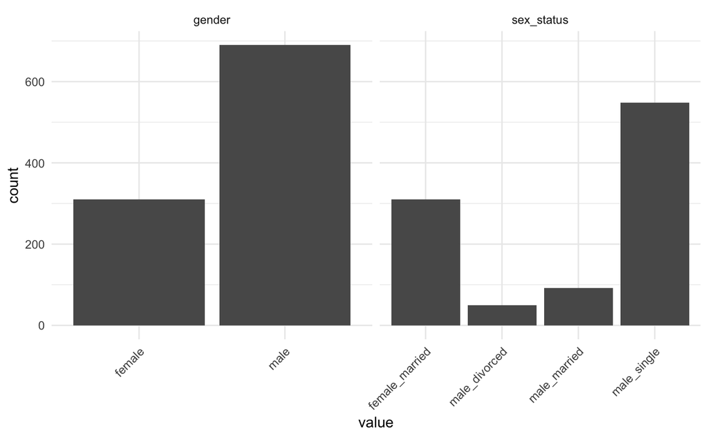

```r
clean_df %>%
    select(sex_status, gender) %>%
    mutate_all(as.character) %>%
    gather(key = "feature") %>%
    ggplot(aes(x = value)) +
    geom_bar() +
    facet_wrap(~ feature, scales = "free_x") +
    theme_minimal() +
    theme(axis.text.x = element_text(angle = 45, vjust = 1, hjust = 1))
```

Keeping both variables doesn’t make intuitive sense, and neither does having a model so imbalanced towards men. Although a tree model would probably distinguish between them I will drop `sex_status` before proceeding.

```r
clean_df$sex_status <- NULL
```

This is the point at which I’ll partition the data, before examining correlations between continuous variables.

```r
set.seed(1705L)
in_train <- createDataPartition(clean_df[["outcome"]],
                                p = 0.8,
                                list = FALSE)
train_df <- clean_df[in_train, ]
test_df <- clean_df[-in_train, ]
```

Now examine correlations between continuous variables.

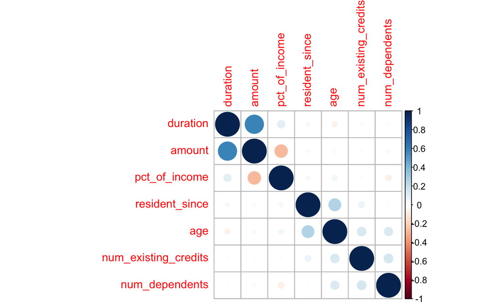

```r
corr_matrix <- train_df %>%
    select_if(is.integer) %>%
    data.matrix() %>%
    cor()
corrplot(corr_matrix)
```

The correlation between `amount` and `duration` seems high, and worth examining further.

```r
cor(train_df$amount, train_df$duration)
```

```
[1] 0.5876622
```

A correlation value of 0.59 is a little high. Which has the closest relationship with `outcome`?

```r
# set up simple logistic regression for each of the variables with outcome
amount_model <- glm(outcome ~ amount,
                    family = binomial(link = "logit"),
                    data = train_df)
duration_model <- glm(outcome ~ duration,
                      family = binomial(link = "logit"),
                      data = train_df)
# examine the summary of residuals
summary(amount_model$residuals)
```

```
     Min.   1st Qu.    Median      Mean   3rd Qu.      Max.
-2.636787 -1.412030 -1.348187  0.005084  2.632647  4.203957
```

```r
summary(duration_model$residuals)
```

```
     Min.   1st Qu.    Median      Mean   3rd Qu.      Max.
-2.778941 -1.466651 -1.298723 -0.004522  2.371781  5.184007
```

# XGBoost with AUC Objective

```r
# create matrices with Matrix::sparse.model.matrix
train_sparse <- sparse.model.matrix(outcome ~ ., data = train_df)
test_sparse <- sparse.model.matrix(outcome ~ ., data = test_df)
# xgboost needs binary numeric labels
train_labels <- if_else(train_df$outcome == "good", 1L, 0L)
test_labels <- if_else(test_df$outcome == "good", 1L, 0L)
# xgb performs best with its own object type
dtrain <- xgb.DMatrix(train_sparse, label = train_labels)
dtest <- xgb.DMatrix(test_sparse, label = test_labels)
# set seed for reproducibility
set.seed(1907L)
# define the folds for cross-validation
cv_folds <- KFold(train_labels, nfolds = 5,
                  stratified = TRUE, seed = 0)
# create a function that will return values for the optimisation
xgb_cv_bayes <- function(max_depth,
                         min_child_weight,
                         subsample,
                         eta,
                         colsample_bytree,
                         lambda,
                         alpha,
                         gamma) {
    cv <- xgb.cv(params = list(booster = "gbtree",
                               eta = eta,
                               max_depth = max_depth,
                               min_child_weight = min_child_weight,
                               subsample = subsample,
                               colsample_bytree = colsample_bytree,
                               lambda = lambda,
                               alpha = alpha,
                               gamma = gamma,
                               objective = "binary:logistic",
                               eval_metric = "auc"),
                 data = dtrain,
                 nrounds = 10000L,
                 folds = cv_folds,
                 prediction = TRUE,
                 showsd = TRUE,
                 early_stopping_rounds = 50L,
                 maximize = TRUE,
                 verbose = 0)
    list(Score = cv$evaluation_log$test_auc_mean[cv$best_iteration],
         Pred = cv$pred)
}
# run optimisation with bounds for the parameters to be tested
if (file.exists("./data/xgb_opt_res.rds")) {
    xgb_opt_res <- read_rds("./data/xgb_opt_res.rds")
} else {
    xgb_opt_res <- BayesianOptimization(xgb_cv_bayes,
                                        bounds = list(
                                            max_depth = c(1L, 15L),
                                            min_child_weight = c(1L, 20L),
                                            subsample = c(0.2, 1.0),
                                            eta = c(0.0001, 0.1),
                                            colsample_bytree = c(0.2, 1),
                                            lambda = c(0.5, 20.0),
                                            alpha = c(0.5, 20.0),
                                            gamma = c(0.0, 20.0)),
                                        init_grid_dt = NULL,
                                        init_points = 10,
                                        n_iter = 40,
                                        acq = "ucb",
                                        kappa = 2.576,
                                        eps = 0.0,
                                        verbose = TRUE)
    write_rds(xgb_opt_res, "./data/xgb_opt_res.rds")
}
```

Now run the cross-validation again with the best parameters found, to have the evaluation log.

```r
xgb_params <- xgb_opt_res[["Best_Par"]]
xgb_param_list <- list(
    eta = xgb_params[["eta"]],
    max_depth = xgb_params[["max_depth"]],
    min_child_weight = xgb_params[["min_child_weight"]],
    subsample = xgb_params[["subsample"]],
    colsample_bytree = xgb_params[["colsample_bytree"]],
    lambda = xgb_params[["lambda"]],
    alpha = xgb_params[["alpha"]],
    gamma = xgb_params[["gamma"]],
    objective = "binary:logistic",
    eval_metric = "auc")
if (file.exists("./data/xgb_cv.rds")) {
    xgb_cv <- read_rds("./data/xgb_cv.rds")
} else {
    xgb_cv <- xgb.cv(params = xgb_param_list,
                     data = dtrain,
                     nrounds = 10000L,
                     folds = cv_folds,
                     prediction = TRUE,
                     showsd = TRUE,
                     early_stopping_rounds = 1000L,
                     print_every_n = 500L,
                     maximize = TRUE)

    write_rds(xgb_cv, "./data/xgb_cv.rds")
}
```

Now I will plot the training progress for cross-validation to detect bias or variance.

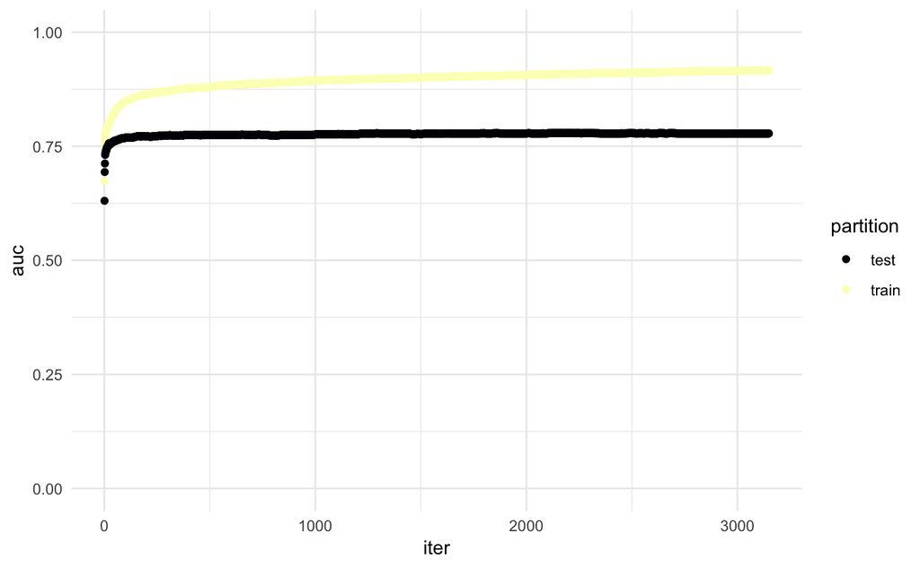

```r
xgb_cv[["evaluation_log"]] %>%
    dplyr::select(iter, train_auc_mean, test_auc_mean) %>%
    gather(key = "partition",
           value = "auc",
           train_auc_mean,
           test_auc_mean) %>%
    mutate(partition = stri_extract_first_regex(partition, "^[a-z]+")) %>%
    ggplot(aes(x = iter, y = auc, colour = partition)) +
    # facet_wrap(~ cv_count) +
    geom_point() +
    scale_colour_viridis(discrete = TRUE, option = "A") +
    ylim(0, 1) +
    theme_minimal()
```

Now train the XGBoost model.

```r
xgb_model <- xgb.train(params = xgb_param_list,
                       data = dtrain,
                       nrounds = xgb_cv[["best_iteration"]],
                       metrics = "auc")
```

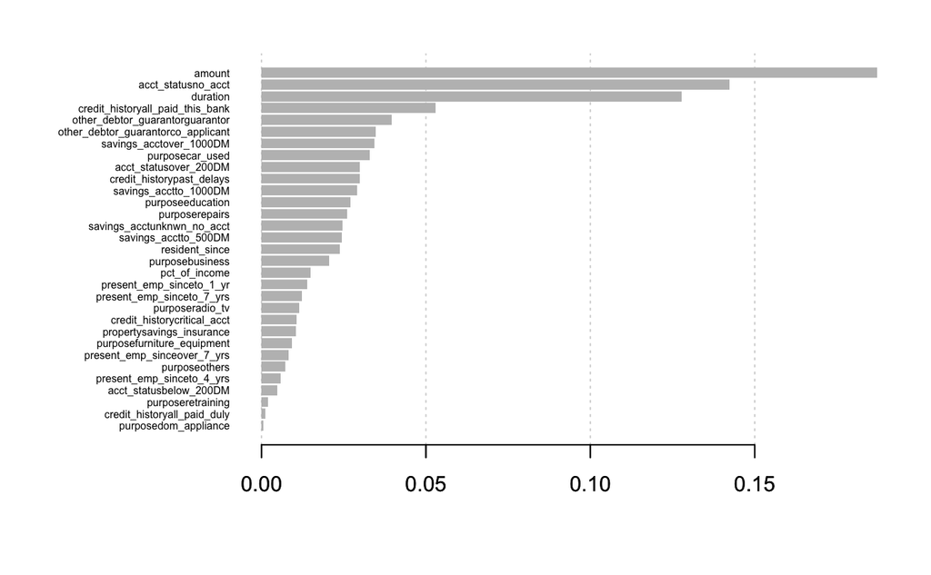

```r
var_importance <- xgb.importance(model = xgb_model)
xgb.plot.importance(var_importance)
```

Now I need to set the prediction threshold on the test set.

```r
xgb_preds <- predict(xgb_model, dtest)
thresholds <- seq(0.01, 0.99, 0.01)
auc_scores <- map_dbl(thresholds,
                      function(x) {
                          tmp_preds <- as.integer(predict(xgb_model, dtest) > x)
                          auc(roc(test_labels, tmp_preds))
                      })
xgb_best_threshold <- thresholds[[which.max(auc_scores)]]
paste0("Threshold that maximises AUC is ", xgb_best_threshold)
```

```
[1] "Threshold that maximises AUC is 0.68"
```

Now evaluate the model on the test set.

```r
xgb_factor_preds <- as.character(xgb_preds > xgb_best_threshold) %>%
    fct_recode(good = "TRUE",
               bad = "FALSE")
xgb_conf_mat <- confusionMatrix(xgb_factor_preds, test_df$outcome)
```

```
Levels are not in the same order for reference and data. Refactoring data to match.
```

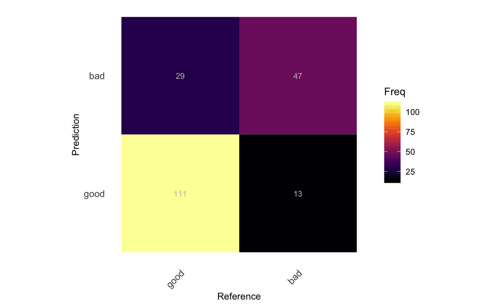

```r
print_conf_matrix(xgb_conf_mat)
```

```r
paste0("AUC is ", round(xgb_conf_mat$byClass[["Balanced Accuracy"]], 3))
```

```
[1] "AUC is 0.788"
```